# Project: Agricultural land area: Changes and Correlations

- Introduction
- Data Wrangling
- Exploratory Data Analysis
- Conclusions

## Introduction

Agriculture is central to how our societies function. The development of agriculture allowed humans to devote time to something other than gathering and hunting food. Farms provide food for our communities. The agricultural industry is also responsible for large amounts of greenhouse gas emissions. Fertilizer production, transportation of food, and livestock management are energy-intensive processes.

For the following investigation, I selected three datasets from Gapminder:

1. agricultural land as a percentage of total land area,
2. annual CO$_2$ emissions in metric tonnes of CO$_2$ per person , and
3. income per person (GDP/capita).

These factors are influenced by a myriad of global and local factors, so correlation might be low. Despite this, I was curious to determine how the amount of agricultural land has changed over time and if those changes correlate with changes in CO$_2$ emissions. If those do not, is GDP a better indicator of CO2 emissions in the time frame of interest?

```python
import pandas as pd
import matplotlib.pyplot as plt

%matplotlib inline
```

## Data Wrangling

These datasets contain information about almost 200 countries and span multiple timeframes. There is lots of missing data.  
The first order of business is cleaning them up!

### General Properties

#### Import data and take a quick look at it

```python
#Load in data and look at it
ag_land = pd.read_csv('agricultural_land_percent_of_land_area.csv').set_index('country').transpose().rename_axis('year')
ag_land.head()
```

| country year | Afghanistan | Albania | Algeria | Andorra | Angola | Antigua and Barbuda | Argentina | Armenia | Australia | Austria | ... | United Kingdom | United States | Uruguay | Uzbekistan | Vanuatu | Venezuela | Vietnam | Yemen | Zambia | Zimbabwe |
| --- | --- | --- | --- | --- | --- | --- | --- | --- | --- | --- | --- | --- | --- | --- | --- | --- | --- | --- | --- | --- | --- |
| 1961 | 0.577 | 0.450 | 0.191 | 0.553 | 0.459 | 0.227 | 0.504 | NaN | 0.601 | 0.431 | ... | 0.818 | 0.489 | 0.934 | NaN | 0.0861 | 0.218 | 0.193 | 0.442 | 0.260 | 0.284 |
| 1962 | 0.578 | 0.450 | 0.189 | 0.553 | 0.459 | 0.205 | 0.499 | NaN | 0.604 | 0.428 | ... | 0.818 | 0.485 | 0.928 | NaN | 0.0861 | 0.219 | 0.193 | 0.442 | 0.260 | 0.286 |
| 1963 | 0.579 | 0.450 | 0.187 | 0.553 | 0.459 | 0.227 | 0.493 | NaN | 0.607 | 0.423 | ... | 0.816 | 0.482 | 0.922 | NaN | 0.0861 | 0.220 | 0.194 | 0.442 | 0.261 | 0.288 |
| 1964 | 0.580 | 0.449 | 0.185 | 0.553 | 0.459 | 0.205 | 0.487 | NaN | 0.611 | 0.421 | ... | 0.814 | 0.479 | 0.919 | NaN | 0.0861 | 0.220 | 0.194 | 0.443 | 0.262 | 0.291 |
| 1965 | 0.580 | 0.451 | 0.185 | 0.553 | 0.459 | 0.250 | 0.482 | NaN | 0.616 | 0.419 | ... | 0.810 | 0.476 | 0.913 | NaN | 0.0927 | 0.221 | 0.194 | 0.443 | 0.262 | 0.292 |

5 rows × 191 columns

```python
#import the CO2 emissions dataset
co2 = pd.read_csv('co2_emissions_tonnes_per_person.csv').set_index('country')

#trim the data to the same years covered by the agricultural land data
#we know CO2 increases over time, we're looking for how CO2 relates to the other datasets
#then, it's reasonable to trim the years not reflected in the other datasets because no comparisons can be made
co2 = co2.loc[:,'1961':'2016'].transpose().rename_axis('year')
co2.head()
```

| country year | Afghanistan | Albania | Algeria | Andorra | Angola | Antigua and Barbuda | Argentina | Armenia | Australia | Austria | ... | United Kingdom | United States | Uruguay | Uzbekistan | Vanuatu | Venezuela | Vietnam | Yemen | Zambia | Zimbabwe |
| --- | --- | --- | --- | --- | --- | --- | --- | --- | --- | --- | --- | --- | --- | --- | --- | --- | --- | --- | --- | --- | --- |
| 1961 | 0.0536 | 1.35 | 0.535 | NaN | 0.0821 | 0.867 | 2.46 | 3.83 | 8.67 | 4.48 | ... | 11.2 | 15.2 | 1.60 | 5.12 | NaN | 6.15 | 0.237 | 0.494 | 1.170 | 1.30 |
| 1962 | 0.0737 | 1.42 | 0.488 | NaN | 0.2100 | 1.840 | 2.54 | 3.89 | 8.92 | 4.74 | ... | 11.2 | 15.5 | 1.54 | 5.21 | 0.595 | 6.19 | 0.269 | 0.710 | 1.100 | 1.21 |
| 1963 | 0.0741 | 1.16 | 0.455 | NaN | 0.2030 | 1.490 | 2.33 | 4.04 | 9.31 | 5.13 | ... | 11.3 | 16.0 | 1.64 | 5.41 | 0.472 | 6.21 | 0.255 | 0.525 | 1.030 | 1.13 |
| 1964 | 0.0861 | 1.09 | 0.462 | NaN | 0.2130 | 1.590 | 2.55 | 4.16 | 9.85 | 5.36 | ... | 11.3 | 16.5 | 1.71 | 5.57 | 0.864 | 6.04 | 0.321 | 0.644 | 0.946 | 1.03 |
| 1965 | 0.1010 | 1.15 | 0.525 | NaN | 0.2060 | 2.560 | 2.66 | 4.28 | 10.70 | 5.23 | ... | 11.5 | 17.0 | 2.05 | 5.70 | 0.642 | 6.27 | 0.348 | 0.686 | 1.100 | 1.17 |

5 rows × 192 columns

#### Examine the data types to ensure all are floats

```python
#inspect data types - this returns that they're all floats
#uncomment any of these to see that both are all float data

#ag_land.dtypes
#ag_gdp.dtypes
```

#### Inspect datasets for missing data

Results are summarized below code blocks.

```python
#Remove either ; to look at missing data by year and by country.
#What data are missing?
ag_land.isna().sum()

#Which years are missing data?
ag_land.transpose().isna().sum();
```

```python
#Remove either ; to look at missing data by year and by country.
#What data are missing?
co2.isna().sum()

#Which years are missing data?
co2.transpose().isna().sum();
```

#### Agricultural land

The code above (when not suppressed with a semicolon) shows that the data are all floats. Additionally, from 1961-1990 30 countries are missing data, between 1992 and 2005 2-8 countries are missing data. There is no missing data from 2005-present. After transposing to look at data by country, I saw that countries either had 0 missing values or ~30 missing values. This suggests that the missing data aren't randomly distributed; some countries only have more recent data.

#### CO$_2$ emissions

Very few countries are missing data on CO$_2$ emissions for the time frame of interest.

### Dataset size, errant data points

Below, we see some quick stats for a handful of the countries. 56 years are represented in this dataset.

```python
ag_land.describe()
```

| country | Afghanistan | Albania | Algeria | Andorra | Angola | Antigua and Barbuda | Argentina | Armenia | Australia | Austria | ... | United Kingdom | United States | Uruguay | Uzbekistan | Vanuatu | Venezuela | Vietnam | Yemen | Zambia | Zimbabwe |
| --- | --- | --- | --- | --- | --- | --- | --- | --- | --- | --- | --- | --- | --- | --- | --- | --- | --- | --- | --- | --- | --- |
| count | 56.000000 | 56.000000 | 56.000000 | 56.000000 | 56.000000 | 56.000000 | 56.000000 | 25.000000 | 56.000000 | 56.000000 | ... | 56.000000 | 56.000000 | 56.000000 | 25.000000 | 56.000000 | 56.000000 | 56.000000 | 56.000000 | 56.000000 | 56.000000 |
| mean | 0.581250 | 0.421054 | 0.174571 | 0.489054 | 0.462125 | 0.200321 | 0.485714 | 0.527040 | 0.594375 | 0.371071 | ... | 0.749107 | 0.462696 | 0.862071 | 0.636200 | 0.122248 | 0.238482 | 0.247357 | 0.445339 | 0.285589 | 0.350464 |
| std | 0.001822 | 0.017978 | 0.009605 | 0.043302 | 0.004593 | 0.025851 | 0.026879 | 0.074702 | 0.039085 | 0.028156 | ... | 0.035842 | 0.012024 | 0.027605 | 0.009704 | 0.023690 | 0.009612 | 0.063161 | 0.002126 | 0.020480 | 0.047973 |
| min | 0.577000 | 0.392000 | 0.162000 | 0.399000 | 0.459000 | 0.159000 | 0.465000 | 0.411000 | 0.476000 | 0.324000 | ... | 0.701000 | 0.442000 | 0.813000 | 0.626000 | 0.086100 | 0.218000 | 0.193000 | 0.442000 | 0.260000 | 0.284000 |
| 25% | 0.580750 | 0.408000 | 0.166000 | 0.485750 | 0.460000 | 0.205000 | 0.469000 | 0.465000 | 0.581250 | 0.350500 | ... | 0.716750 | 0.452000 | 0.847750 | 0.629000 | 0.101850 | 0.230000 | 0.200000 | 0.444000 | 0.268500 | 0.311750 |
| 50% | 0.581000 | 0.413500 | 0.173500 | 0.489000 | 0.460000 | 0.205000 | 0.471000 | 0.529000 | 0.607000 | 0.367000 | ... | 0.750500 | 0.466000 | 0.854000 | 0.631000 | 0.121500 | 0.244000 | 0.211000 | 0.445000 | 0.278000 | 0.334000 |
| 75% | 0.583000 | 0.438000 | 0.185000 | 0.511000 | 0.461250 | 0.205000 | 0.494500 | 0.591000 | 0.620250 | 0.386500 | ... | 0.768500 | 0.471000 | 0.873500 | 0.643000 | 0.146500 | 0.245000 | 0.305750 | 0.447000 | 0.304500 | 0.401250 |
| max | 0.583000 | 0.454000 | 0.191000 | 0.553000 | 0.475000 | 0.250000 | 0.545000 | 0.617000 | 0.635000 | 0.431000 | ... | 0.818000 | 0.489000 | 0.934000 | 0.652000 | 0.153000 | 0.250000 | 0.393000 | 0.450000 | 0.321000 | 0.425000 |

8 rows × 191 columns

```python
co2.describe()
```

| country | Afghanistan | Albania | Algeria | Andorra | Angola | Antigua and Barbuda | Argentina | Armenia | Australia | Austria | ... | United Kingdom | United States | Uruguay | Uzbekistan | Vanuatu | Venezuela | Vietnam | Yemen | Zambia | Zimbabwe |
| --- | --- | --- | --- | --- | --- | --- | --- | --- | --- | --- | --- | --- | --- | --- | --- | --- | --- | --- | --- | --- | --- |
| count | 56.000000 | 56.000000 | 56.000000 | 27.000000 | 56.000000 | 56.000000 | 56.000000 | 56.000000 | 56.000000 | 56.000000 | ... | 56.000000 | 56.000000 | 56.000000 | 56.000000 | 55.000000 | 56.000000 | 56.000000 | 56.000000 | 56.000000 | 56.000000 |
| mean | 0.149559 | 1.646107 | 2.531589 | 6.824815 | 0.657948 | 5.346375 | 3.703393 | 3.408214 | 15.266964 | 7.477143 | ... | 9.919286 | 19.423214 | 1.770536 | 5.325000 | 0.514673 | 5.979643 | 0.673518 | 0.715554 | 0.508536 | 1.191804 |
| std | 0.088935 | 0.650075 | 1.031690 | 0.701166 | 0.355507 | 3.100566 | 0.586665 | 1.905369 | 3.086224 | 1.217837 | ... | 1.382136 | 1.737709 | 0.350446 | 1.018653 | 0.162260 | 0.656863 | 0.488121 | 0.276370 | 0.345324 | 0.305023 |
| min | 0.036800 | 0.498000 | 0.455000 | 5.830000 | 0.082100 | 0.867000 | 2.330000 | 0.766000 | 8.670000 | 4.480000 | ... | 6.040000 | 15.200000 | 1.050000 | 2.900000 | 0.222000 | 4.220000 | 0.237000 | 0.234000 | 0.149000 | 0.441000 |
| 25% | 0.074000 | 1.252500 | 1.967500 | 6.120000 | 0.446750 | 4.122500 | 3.460000 | 1.487500 | 12.700000 | 6.972500 | ... | 9.527500 | 18.325000 | 1.555000 | 4.560000 | 0.433000 | 5.685000 | 0.317750 | 0.509000 | 0.223000 | 0.968750 |
| 50% | 0.142500 | 1.555000 | 2.965000 | 6.750000 | 0.567500 | 4.920000 | 3.670000 | 4.100000 | 16.100000 | 7.660000 | ... | 10.050000 | 20.000000 | 1.770000 | 5.395000 | 0.472000 | 6.040000 | 0.470500 | 0.722000 | 0.346000 | 1.245000 |
| 75% | 0.215250 | 2.075000 | 3.285000 | 7.340000 | 0.759750 | 5.850000 | 4.022500 | 5.377500 | 17.850000 | 8.240000 | ... | 10.850000 | 20.725000 | 2.012500 | 6.212500 | 0.547500 | 6.247500 | 0.864250 | 0.889500 | 0.838000 | 1.427500 |
| max | 0.406000 | 2.890000 | 3.800000 | 8.020000 | 1.640000 | 19.800000 | 4.700000 | 5.790000 | 19.300000 | 9.630000 | ... | 11.900000 | 22.200000 | 2.550000 | 6.740000 | 1.070000 | 7.690000 | 1.960000 | 1.940000 | 1.260000 | 1.670000 |

8 rows × 192 columns

#### Remove countries not present in all three datasets

The above datasets are all different sizes (as shown in the output). More specifically, some datasets have countries not included in other datasets. Because there are only a small number of countries not shared by both datasets, I will remove these countries.

```python
missing_countries = pd.Series(ag_land.columns.symmetric_difference(co2.columns.values))
missing_countries
```

```
0     San Marino
1    South Sudan
2          Sudan
Name: country, dtype: object
```

```python
ag_land_trim = ag_land.drop(columns=missing_countries, errors='ignore')
co2_trim = co2.drop(columns=missing_countries, errors='ignore')

#use shape to ensure these datasets are now all the same size
ag_land_trim.shape, co2_trim.shape
```

```
((56, 190), (56, 190))
```

Now, both datasets cover the same 56 years and the same 190 countries.

```python
#check that all the column headings are the same
sum(ag_land_trim.columns.values != co2_trim.columns.values)
```

```
0
```

## Exploratory Data Analysis

Now, I'd like to look into some trends in the data. I know that CO2 values increase over time. How do agricultural lands change? Does this change correlate with the CO$_2$ emissions changes?

### Research question 1: Does the amount of land used for agriculture change over time?

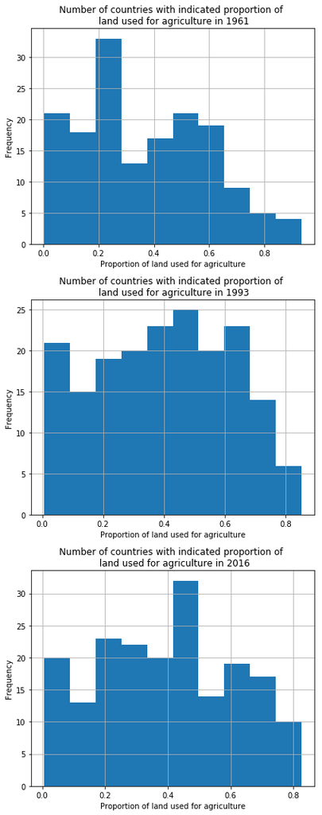

```python
fig1, (ax1a,ax1b,ax1c) = plt.subplots(3)
fig1.set_size_inches(6,15)
#plt.subplots_adjust(wspace=2)

histtitle = 'Number of countries with indicated proportion of \n land used for agriculture in '

#plot 1961 data
ag_land_trim.iloc[0].transpose().hist(ax=ax1a)
ax1a.set_xlabel('Proportion of land used for agriculture')
ax1a.set_ylabel('Frequency')
ax1a.title.set_text(histtitle+'1961')

#plot 1993 data
ag_land_trim.loc['1993'].transpose().hist(ax=ax1b)
ax1b.set_xlabel('Proportion of land used for agriculture')
ax1b.set_ylabel('Frequency')
ax1b.title.set_text(histtitle+'1993')

#plot 2016 data
ag_land_trim.iloc[-1].transpose().hist(ax=ax1c)
ax1c.set_xlabel('Proportion of land used for agriculture')
ax1c.set_ylabel('Frequency')
ax1c.title.set_text(histtitle+'2016')

plt.tight_layout()

plt.show()
```

#### Thoughts

In the newer data, there are more countries with more land set aside for agriculture. From these histograms, it isn't possible to discern whether countries are adding more land for agriculture or whether the countries added after 1961 (30 missing countries) tend to use more of their land for agriculture. Despite this, the data do skew right in 1961 and seem somewhat more evenly distributed in 1993 (4 missing countries) and 2016 (0 missing countries). 1993, with only 4 missing data points, shows a roughly even distribution.

I'd like to be able to focus in a little more on countries who have significantly changed the amount of land they are using for agriculture.

### Research question 2: Is the change in agricultural land reflected in CO$_2$ emissions for a country?

Because agriculture can be responsible for a larger percentage of greenhouse gas emissions, I'm curious to see if changes in agricultural land area are reflected in CO$_2$ emissions. To answer this question, I first filtered the data so that I was only using countries whose agricultural land area had changed by at least 25%. This made these large datasets a little easier to visually compare. Then, I plotted change in agricultural land area and change in CO$_2$ emissions for the countries that added and lost land for agriculture.

```python
#first calculate max change in % agricultural land
ag_land_diff = ag_land_trim.append(pd.Series(ag_land_trim.max()-ag_land_trim.min(),name='max_diff'))
ag_land_diff.tail()
```

| country year | Afghanistan | Albania | Algeria | Andorra | Angola | Antigua and Barbuda | Argentina | Armenia | Australia | Austria | ... | United Kingdom | United States | Uruguay | Uzbekistan | Vanuatu | Venezuela | Vietnam | Yemen | Zambia | Zimbabwe |
| --- | --- | --- | --- | --- | --- | --- | --- | --- | --- | --- | --- | --- | --- | --- | --- | --- | --- | --- | --- | --- | --- |
| 2013 | 0.581 | 0.433 | 0.174 | 0.400 | 0.475 | 0.205 | 0.545 | 0.591 | 0.516 | 0.329 | ... | 0.713 | 0.444 | 0.826 | 0.629 | 0.1530 | 0.245 | 0.350 | 0.446 | 0.319 | 0.419 |
| 2014 | 0.581 | 0.429 | 0.174 | 0.400 | 0.475 | 0.205 | 0.543 | 0.590 | 0.529 | 0.329 | ... | 0.712 | 0.446 | 0.826 | 0.629 | 0.1530 | 0.245 | 0.392 | 0.446 | 0.321 | 0.419 |
| 2015 | 0.581 | 0.429 | 0.174 | 0.400 | 0.475 | 0.205 | 0.543 | 0.589 | 0.476 | 0.329 | ... | 0.708 | 0.444 | 0.826 | 0.629 | 0.1530 | 0.245 | 0.393 | 0.446 | 0.321 | 0.419 |
| 2016 | 0.581 | 0.431 | 0.174 | 0.400 | 0.475 | 0.205 | 0.543 | 0.589 | 0.482 | 0.324 | ... | 0.717 | 0.444 | 0.826 | 0.629 | 0.1530 | 0.245 | 0.393 | 0.446 | 0.321 | 0.419 |
| max_diff | 0.006 | 0.062 | 0.029 | 0.154 | 0.016 | 0.091 | 0.080 | 0.206 | 0.159 | 0.107 | ... | 0.117 | 0.047 | 0.121 | 0.026 | 0.0669 | 0.032 | 0.200 | 0.008 | 0.061 | 0.141 |

5 rows × 190 columns

```python
#next, trim the dataset to focus on the countries with at least a 25% land area change in the last 56 years
ag_land_diff = ag_land_diff.transpose().query('max_diff>0.25').transpose()

#then remove the calculated column
ag_land_diff = ag_land_diff.drop(index=['max_diff'])
ag_land_diff.tail()
```

| country year | Costa Rica | Cuba | Cyprus | Grenada | Italy | Malawi | Malta | New Zealand | Nigeria | Paraguay | Saudi Arabia | St. Kitts and Nevis | Uganda |
| --- | --- | --- | --- | --- | --- | --- | --- | --- | --- | --- | --- | --- | --- |
| 2012 | 0.355 | 0.602 | 0.127 | 0.235 | 0.467 | 0.608 | 0.322 | 0.426 | 0.791 | 0.541 | 0.806 | 0.231 | 0.721 |
| 2013 | 0.352 | 0.609 | 0.118 | 0.235 | 0.463 | 0.614 | 0.320 | 0.422 | 0.777 | 0.546 | 0.806 | 0.231 | 0.719 |
| 2014 | 0.349 | 0.604 | 0.118 | 0.235 | 0.447 | 0.614 | 0.320 | 0.422 | 0.777 | 0.551 | 0.807 | 0.231 | 0.719 |
| 2015 | 0.349 | 0.600 | 0.138 | 0.235 | 0.440 | 0.614 | 0.320 | 0.412 | 0.777 | 0.551 | 0.808 | 0.231 | 0.719 |
| 2016 | 0.345 | 0.599 | 0.122 | 0.235 | 0.432 | 0.614 | 0.324 | 0.405 | 0.777 | 0.551 | 0.808 | 0.231 | 0.719 |

```python
#create two new dataframes for countries whose land area has increased and decreased
ag_land_inc = ag_land_diff.transpose().rename(columns = lambda x: 'y'+ str(x)).query('y2016 > y1961').rename(columns = lambda x: x[1:]).transpose()
ag_land_dec = ag_land_diff.transpose().rename(columns = lambda x: 'y'+ str(x)).query('y2016 < y1961').rename(columns = lambda x: x[1:]).transpose()
ag_land_inc.head()

#note to self: newer .query can access numerical column names using backticks
```

| country year | Costa Rica | Cuba | Malawi | Nigeria | Paraguay | Saudi Arabia | Uganda |
| --- | --- | --- | --- | --- | --- | --- | --- |
| 1961 | 0.273 | 0.331 | 0.339 | 0.584 | 0.262 | 0.401 | 0.451 |
| 1962 | 0.276 | 0.354 | 0.350 | 0.592 | 0.265 | 0.401 | 0.456 |
| 1963 | 0.278 | 0.376 | 0.355 | 0.615 | 0.268 | 0.401 | 0.463 |
| 1964 | 0.291 | 0.443 | 0.361 | 0.626 | 0.271 | 0.401 | 0.494 |
| 1965 | 0.305 | 0.423 | 0.382 | 0.649 | 0.274 | 0.401 | 0.494 |

```python
inc_countries = list(ag_land_inc.columns.values)
dec_countries = list(ag_land_dec.columns.values)
inc_countries, dec_countries
```

```
(['Costa Rica',
  'Cuba',
  'Malawi',
  'Nigeria',
  'Paraguay',
  'Saudi Arabia',
  'Uganda'],
 ['Cyprus', 'Grenada', 'Italy', 'Malta', 'New Zealand', 'St. Kitts and Nevis'])
```

```python
#create a clipped version of the CO2 dataset focusing on
#the countries and years of interest from the ag land findings

co2_ag_inc = co2_trim.transpose().loc[:,'1960':].copy().query('country in @inc_countries').transpose()
co2_ag_dec = co2_trim.transpose().loc[:,'1960':].copy().query('country in @dec_countries').transpose()

co2_ag_inc.head()
```

| country year | Costa Rica | Cuba | Malawi | Nigeria | Paraguay | Saudi Arabia | Uganda |
| --- | --- | --- | --- | --- | --- | --- | --- |
| 1961 | 0.356 | 1.67 | 0.0997 | 0.0893 | 0.186 | 0.847 | 0.0582 |
| 1962 | 0.384 | 1.90 | 0.0940 | 0.0888 | 0.196 | 1.430 | 0.0594 |
| 1963 | 0.405 | 1.71 | 0.0882 | 0.1110 | 0.199 | 1.540 | 0.0580 |
| 1964 | 0.438 | 1.83 | 0.0818 | 0.1480 | 0.204 | 1.510 | 0.0636 |
| 1965 | 0.532 | 1.84 | 0.0842 | 0.2350 | 0.253 | 0.871 | 0.0785 |

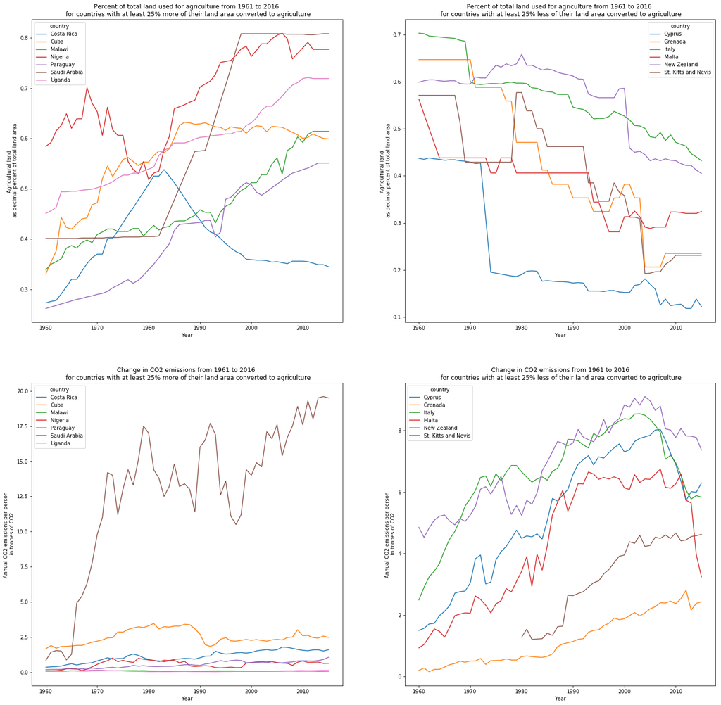

```python
#plot the changes in land area over time for these two smaller dataframes
fig2, ((ax2a, ax2b), (ax2c, ax2d)) = plt.subplots(2, 2)
fig2.set_size_inches(24, 24)
plt.subplots_adjust(wspace=0.2)

title1 = 'Percent of total land used for agriculture from 1961 to 2016 \n for countries with at least 25% more of their land area converted to agriculture'
title2 = 'Percent of total land used for agriculture from 1961 to 2016 \n for countries with at least 25% less of their land area converted to agriculture'
title3 = 'Change in CO2 emissions from 1961 to 2016 \n for countries with at least 25% more of their land area converted to agriculture'
title4 = 'Change in CO2 emissions from 1961 to 2016\n for countries with at least 25% less of their land area converted to agriculture'

ag_land_inc.plot(ax=ax2a, title=title1)
ax2a.set_xlabel('Year')
ax2a.set_ylabel('Agricultural land \n as decimal percent of total land area')
ax2a.set_xticklabels(['','1960','1970','1980','1990','2000','2010'])

ag_land_dec.plot(ax=ax2b, title=title2)
ax2b.set_xlabel('Year')
ax2b.set_ylabel('Agricultural land \n as decimal percent of total land area')
ax2b.set_xticklabels(['','1960','1970','1980','1990','2000','2010'])

co2_ag_inc.plot(ax=ax2c, title=title3)
ax2c.set_xlabel('Year')
ax2c.set_ylabel('Annual CO2 emissions per person \n in tonnes of CO2')
ax2c.set_xticklabels(['','1960','1970','1980','1990','2000','2010'])

co2_ag_dec.plot(ax=ax2d, title=title4)
ax2d.set_xlabel('Year')
ax2d.set_ylabel('Annual CO2 emissions per person \n in tonnes of CO2')
ax2d.set_xticklabels(['','1960','1970','1980','1990','2000','2010']);
```

#### Observations

##### Land increase

Saudi Arabia has significantly increased the amount of land devoted to agriculture and also emitted far more CO$_2$ in 2016 than in 1961. I believe they have set up some large-scale irrigation efforts, so the increase in arable land makes sense. The CO$_2$ could be related to agriculture or to other changes. Costa Rica shows a huge spike in land area the 1980s, then a more recent drop in agricultural land area. This may correlate with a spike in its CO$_2$ emissions, but it is difficult to tell because the Saudi Arabia data swamps the scale of the graph. Otherwise, the overall trend is gradually increasing amounts of land used for agriculture and CO$_2$ emissions.

#### What about countries with the highest CO$_2$ emissions?

Finally, I will select the countries with the highest CO$_2$ emissions. These countries, together with those above, will be used to create a plot comparing changes in CO$_2$ emissions to agricultural land area.

```python
co2_high_emissions = co2.transpose().rename(columns = lambda x: 'y'+ str(x)).query('y2016 > 10').rename(columns = lambda x: x[1:]).transpose()
high_co2_countries = co2_high_emissions.columns.values
high_co2_countries
```

```
array(['Australia', 'Bahrain', 'Brunei', 'Canada', 'Estonia', 'Iceland',
       'Kazakhstan', 'Kuwait', 'Luxembourg', 'Oman', 'Palau', 'Qatar',
       'Russia', 'Saudi Arabia', 'South Korea', 'Trinidad and Tobago',
       'Turkmenistan', 'United Arab Emirates', 'United States'], dtype=object)
```

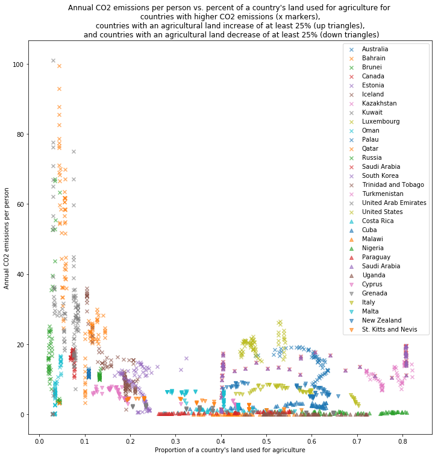

```python
bigtitle = 'Annual CO2 emissions per person vs. percent of a country\'s land used for agriculture for \n countries with higher CO2 emissions (x markers), \n countries with an agricultural land increase of at least 25% (up triangles), \n and countries with an agricultural land decrease of at least 25% (down triangles)'
fig6 = plt.figure(figsize=(12,12))
ax6 = fig6.add_subplot(111)

for c in high_co2_countries:
    ax6.scatter(ag_land_trim.loc[:,c],co2_trim.loc[:,c], label = c, marker = 'x', alpha = .6)

for c in ag_land_inc:
    ax6.scatter(ag_land_trim.loc[:,c],co2_trim.loc[:,c], label = c, marker = '^', alpha = .6)

for c in ag_land_dec:
    ax6.scatter(ag_land_trim.loc[:,c],co2_trim.loc[:,c], label = c, marker = 'v', alpha = .6)

ax6.set_xlabel('Proportion of a country\'s land used for agriculture')
ax6.set_ylabel('Annual CO2 emissions per person')
plt.legend(loc = 'upper right')
plt.title(bigtitle)

plt.show()
```

```python
# This plot (for all the countries) shows the same general shape as the one used above, so it is commented out
#fig3 = plt.figure(figsize=(12,12))
#ax3 = fig3.add_subplot(111)

#for n in ag_land_trim.columns.values:
#    ax3.scatter(ag_land_trim.loc[:,n],co2_trim.loc[:,n], alpha = .6)

#ax3.set_xlabel('Percent of a country\'s land used for agriculture')
#ax3.set_ylabel('Annual CO2 emissions per person per year')

#plt.show()
```

#### Observations

There are some interesting trends here:

1. countries with high CO2 emissions tend to not have much of their land used for agriculture
2. countries with low CO$_2$ emissions are more likely to devote more of their land to agriculture
3. Countries that have added agricultural land are more likely to be low CO$_2$ emitters
4. Countries that emit more CO$_2$ have changed the amount of CO$_2$ they emit to a much greater degree than the other countries plotted here
5. Strongly agricultural countries are not the greatest emitters
6. Many countries whose agricultural land area decreases still see a general increase in CO$_2$ emissions.

When taken together, these data do not show a strong correlation between a country's CO$_2$ emissions and agricultural land. Rather, they both change incrementally over time.

### Research question 3: Is GDP a better indicator for CO$_2$ emissions?

The agricultural data do not show the correlation I expected. That's great. I learned something new. However, if agricultural land area doesn't correlate with increasing CO$_2$ emissions, I'm curious to find something that does. Below, I've imported another data set, GDP per capita, to see if there is a correlation between this and the CO$_2$ emissions. I also plot the GDP per capita and agricultural land data together to see if there are relationships there that may help me better understand the factors at play in this investigation.

```python
#import the gdp dataset, which records country's GDP per capita
gdp = pd.read_csv('income_per_person_gdppercapita_ppp_inflation_adjusted.csv').set_index('country')
gdp.head()

#trim the data to the same years covered by the agricultural land data
gdp = gdp.loc[:,'1961':'2016'].transpose().rename_axis('year')
gdp_trim = gdp.drop(columns = missing_countries, errors='ignore')

gdp_trim.head()
```

| country year | Afghanistan | Albania | Algeria | Andorra | Angola | Antigua and Barbuda | Argentina | Armenia | Australia | Austria | ... | United Kingdom | United States | Uruguay | Uzbekistan | Vanuatu | Venezuela | Vietnam | Yemen | Zambia | Zimbabwe |
| --- | --- | --- | --- | --- | --- | --- | --- | --- | --- | --- | --- | --- | --- | --- | --- | --- | --- | --- | --- | --- | --- |
| 1961 | 2700 | 2610 | 7780 | 16500 | 4310 | 4570 | 10300 | 3120 | 15700 | 11900 | ... | 13900 | 18200 | 7600 | 3290 | 1490 | 13800 | 1200 | 1530 | 2820 | 1590 |
| 1962 | 2680 | 2690 | 4910 | 17800 | 4130 | 4730 | 9980 | 3150 | 16300 | 12100 | ... | 13900 | 19000 | 7360 | 3330 | 1510 | 14500 | 1300 | 1540 | 2710 | 1570 |
| 1963 | 2670 | 2790 | 6030 | 19200 | 4280 | 4890 | 9590 | 3030 | 16900 | 12500 | ... | 14400 | 19500 | 7300 | 3220 | 1530 | 14900 | 1300 | 1550 | 2700 | 1520 |
| 1964 | 2650 | 2880 | 6460 | 20800 | 4700 | 5060 | 10400 | 3380 | 17700 | 13200 | ... | 15000 | 20300 | 7340 | 3590 | 1550 | 15800 | 1320 | 1560 | 2980 | 1630 |
| 1965 | 2640 | 2990 | 6850 | 22500 | 4970 | 5230 | 11200 | 3520 | 18200 | 13600 | ... | 15300 | 21400 | 7330 | 3760 | 1570 | 16100 | 1290 | 1570 | 3430 | 1690 |

5 rows × 190 columns

```python
gdp_trim.dtypes;
```

```python
gdp_trim.describe()
```

| country | Afghanistan | Albania | Algeria | Andorra | Angola | Antigua and Barbuda | Argentina | Armenia | Australia | Austria | ... | United Kingdom | United States | Uruguay | Uzbekistan | Vanuatu | Venezuela | Vietnam | Yemen | Zambia | Zimbabwe |
| --- | --- | --- | --- | --- | --- | --- | --- | --- | --- | --- | --- | --- | --- | --- | --- | --- | --- | --- | --- | --- | --- |
| count | 56.000000 | 56.000000 | 56.000000 | 56.000000 | 56.000000 | 56.000000 | 56.000000 | 56.000000 | 56.000000 | 56.000000 | ... | 56.000000 | 56.000000 | 56.000000 | 56.000000 | 56.000000 | 56.000000 | 56.000000 | 56.000000 | 56.000000 | 56.000000 |
| mean | 1842.964286 | 5314.464286 | 10218.214286 | 32105.357143 | 4965.714286 | 14129.821429 | 14226.250000 | 4378.214286 | 29367.857143 | 29721.428571 | ... | 26230.357143 | 36053.571429 | 11176.607143 | 3705.000000 | 2349.821429 | 16171.428571 | 2203.928571 | 3245.714286 | 2748.928571 | 2385.892857 |
| std | 661.583059 | 2538.252742 | 2212.641455 | 7140.980825 | 970.008167 | 6848.247949 | 2646.479351 | 1660.023118 | 8525.301533 | 10714.267706 | ... | 8368.467214 | 10865.440865 | 3757.972508 | 914.010145 | 472.342291 | 1602.352167 | 1405.530218 | 911.565800 | 512.202654 | 460.678459 |
| min | 646.000000 | 2610.000000 | 4910.000000 | 16500.000000 | 3060.000000 | 4570.000000 | 9590.000000 | 1850.000000 | 15700.000000 | 11900.000000 | ... | 13900.000000 | 18200.000000 | 7130.000000 | 2250.000000 | 1490.000000 | 12000.000000 | 1020.000000 | 1530.000000 | 2030.000000 | 1480.000000 |
| 25% | 1217.500000 | 3687.500000 | 8910.000000 | 27875.000000 | 4255.000000 | 7142.500000 | 12500.000000 | 3370.000000 | 22925.000000 | 20900.000000 | ... | 19050.000000 | 26500.000000 | 8207.500000 | 3062.500000 | 1997.500000 | 15175.000000 | 1177.500000 | 2627.500000 | 2275.000000 | 1967.500000 |
| 50% | 1980.000000 | 4245.000000 | 10350.000000 | 31750.000000 | 4945.000000 | 16400.000000 | 13950.000000 | 4130.000000 | 28050.000000 | 29700.000000 | ... | 26200.000000 | 36000.000000 | 9985.000000 | 3705.000000 | 2530.000000 | 15900.000000 | 1405.000000 | 3555.000000 | 2705.000000 | 2510.000000 |
| 75% | 2512.500000 | 6332.500000 | 11800.000000 | 35000.000000 | 5637.500000 | 20025.000000 | 15375.000000 | 4500.000000 | 36750.000000 | 39650.000000 | ... | 34950.000000 | 46225.000000 | 13000.000000 | 4432.500000 | 2712.500000 | 17325.000000 | 2892.500000 | 3862.500000 | 3152.500000 | 2720.000000 |
| max | 2700.000000 | 11400.000000 | 13900.000000 | 48200.000000 | 6810.000000 | 26500.000000 | 19800.000000 | 8170.000000 | 44600.000000 | 44700.000000 | ... | 39400.000000 | 53600.000000 | 20200.000000 | 5880.000000 | 2980.000000 | 19700.000000 | 5900.000000 | 4570.000000 | 3700.000000 | 3100.000000 |

8 rows × 190 columns

```python
#Remove either ; to look at missing data by year and by country.
#What data are missing?
gdp_trim.isna().sum()

#Which years are missing data?
gdp_trim.transpose().isna().sum();
```

#### GDP per capita

There is no missing data. The data largely seems in good shape. Unlike the previous two datasets, the GDP per capita data is integers.

Now I'd like to plot the GDP data to see if it shows a stronger correlation with the increasing CO2 emissions. Surely *something* correlates with CO2 emissions!

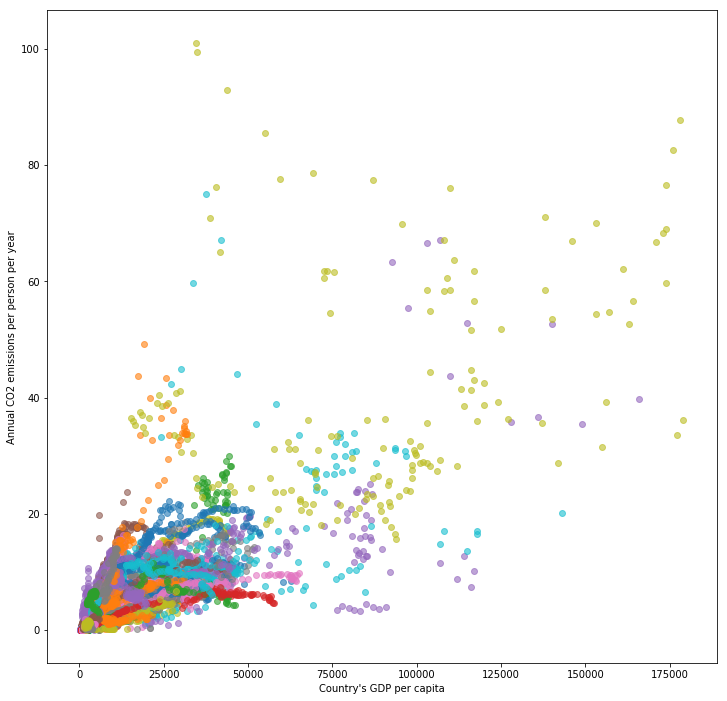

```python
#Plot GDP per capita vs. CO2 emissions
fig4 = plt.figure(figsize=(12,12))
ax4 = fig4.add_subplot(111)

for n in gdp_trim.columns.values:
    if n in co2_trim:
        ax4.scatter(gdp_trim.loc[:,n],co2_trim.loc[:,n], alpha = .6)
    else:
        continue

ax4.set_xlabel('Country\'s GDP per capita')
ax4.set_ylabel('Annual CO2 emissions per person per year')

plt.show()
```

#### GDP per capita

Finally! A correlation. Generally, it looks like an increase in CO$_2$ emissions correlates with an increase in GDP. Note that I did not include a legend on this graph. With 190 countries, there are too many to clearly see which points belong to which country. Instead, I left it like this to show the general positive correlation among countries.

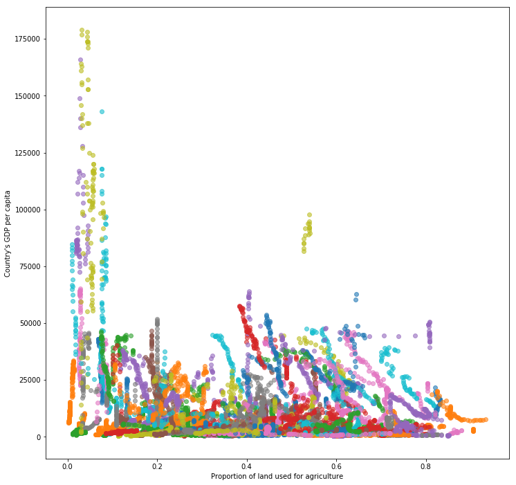

```python
#Plot GDP per capita vs. CO2 emissions
fig7 = plt.figure(figsize=(12,12))
ax7 = fig7.add_subplot(111)

for n in gdp_trim.columns.values:
    if n in ag_land_trim:
        ax7.scatter(ag_land_trim.loc[:,n],gdp_trim.loc[:,n], alpha = .6)
    else:
        continue

ax7.set_xlabel('Proportion of land used for agriculture')
ax7.set_ylabel('Country\'s GDP per capita')

plt.show()
```

#### Observations

That's about what I expected (though the correlation is weaker than I had hoped). There is some indication that countries with more land used for agriculture have a lower GDP/capita. Perhaps these countries have more small-scale local and family farms instead of larger industrial farms used to feed larger populations. With the data focused on just the years since 1961, there's no good way to see a country shift from farming to business or other industries to get a better sense for how that may play out.

### Research Question 4: A United States Case Study

Because these data sets capture so many countries, I'd also like to look specifically at the United States to see what is happening at the single country level. This removes a lot of the potential for variability that exists between different geographic locations, cultures, economies, etc.

```python
#merge the United States data from each of the three datasets to compare together
us = {'ag_land':ag_land_trim['United States'], 'co2':co2_trim['United States'], 'gdp':gdp_trim['United States']}
unitedstates= pd.concat(us, axis=1)
unitedstates.describe()
```

|  | ag_land | co2 | gdp |
| --- | --- | --- | --- |
| count | 56.000000 | 56.000000 | 56.000000 |
| mean | 0.462696 | 19.423214 | 36053.571429 |
| std | 0.012024 | 1.737709 | 10865.440865 |
| min | 0.442000 | 15.200000 | 18200.000000 |
| 25% | 0.452000 | 18.325000 | 26500.000000 |
| 50% | 0.466000 | 20.000000 | 36000.000000 |
| 75% | 0.471000 | 20.725000 | 46225.000000 |
| max | 0.489000 | 22.200000 | 53600.000000 |

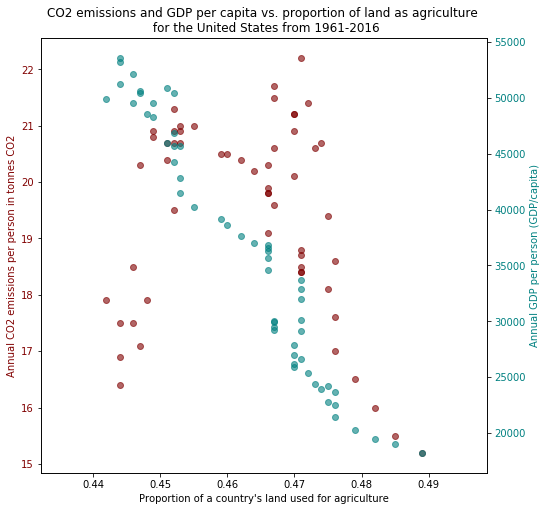

```python
#plot the US data
fig5 = plt.figure(figsize=(8,8))
ax5 = fig5.add_subplot(111)

y1='Annual CO2 emissions per person in tonnes CO2'
y2='Annual GDP per person (GDP/capita)'

ax5.scatter(unitedstates['ag_land'],unitedstates['co2'], label = c, marker = 'o', color='maroon', alpha = .6)
ax5.set_ylabel(y1, color='maroon')

ax5b = ax5.twinx()
ax5b.scatter(unitedstates['ag_land'],unitedstates['gdp'], label = c, marker = 'o', color = 'teal', alpha = .6)
ax5b.set_ylabel(y2, color='teal')

for tl in ax5.get_yticklabels():
    tl.set_color('maroon')

for tl in ax5b.get_yticklabels():
    tl.set_color('teal')

ax5.set_xlabel('Proportion of a country\'s land used for agriculture')
plt.title('CO2 emissions and GDP per capita vs. proportion of land as agriculture \n for the United States from 1961-2016')

plt.show()
```

## Conclusions

#### Question 1: How has the proportion of land used for agriculture over time?

It appears that there are more countries now that have more land used for agriculture. However, this could easily reflect a sampling bias as the data from 1961 is missing ~30 countries.

#### Question 2: Is the change in agricultural land reflected in CO$_2$ emissions for a country?

While there are some general trends showing that countries with high emissions are more likely to have less agriculture and countries with more agriculture are somewhat more likely to have lower emissions (the opposite of what I expected). One country that was a noteable exception to this is Saudi Arabia. Saudi Arabia has significantly increased the amount of land used for agriculture and their CO2 emissions in the last 56 years.

#### Question 3: Is GDP a better indicator for CO$_2$ emissions?

Yes. Generally speaking, countries with higher GDP have higher CO$_2$ emissions. Countries with higher GDP also tend to use less of their land for agriculture.

#### Question 4: A United States case study.

The United States has lost agricultural land over the years (the time component of this is not visible from the plot, but was observed in the raw data). It has also increased its GDP and its CO$_2$ emissions. It shows a trend opposite of what I expected.

### Final Thoughts

I'll admit, I thought there would be somewhat more correlation between these, but these factors are all so large and influenced by so many factors, it is not surprising that it is difficult to see large-scale correlations. It is worth noting that my perceptions going in to this investigation were driven by industrial-style agriculture. This is not reflected in the data. They show only agricultural land percentage. Thus, countries with many small-scale locally-focused farms would have very high agricultural areas, but are likely to be much lower CO$_2$ emitters. When focusing on a single country (the US), there is some more significant correlation (still opposite of my hypothesis), but very little is present on a larger scale.

```python
from subprocess import call
call(['python', '-m', 'nbconvert', 'Investigate_a_Dataset.ipynb'])
```